# Lameness Data Analysis Report

# Impact of Season

## Non-Infectious Lesions

**2024**

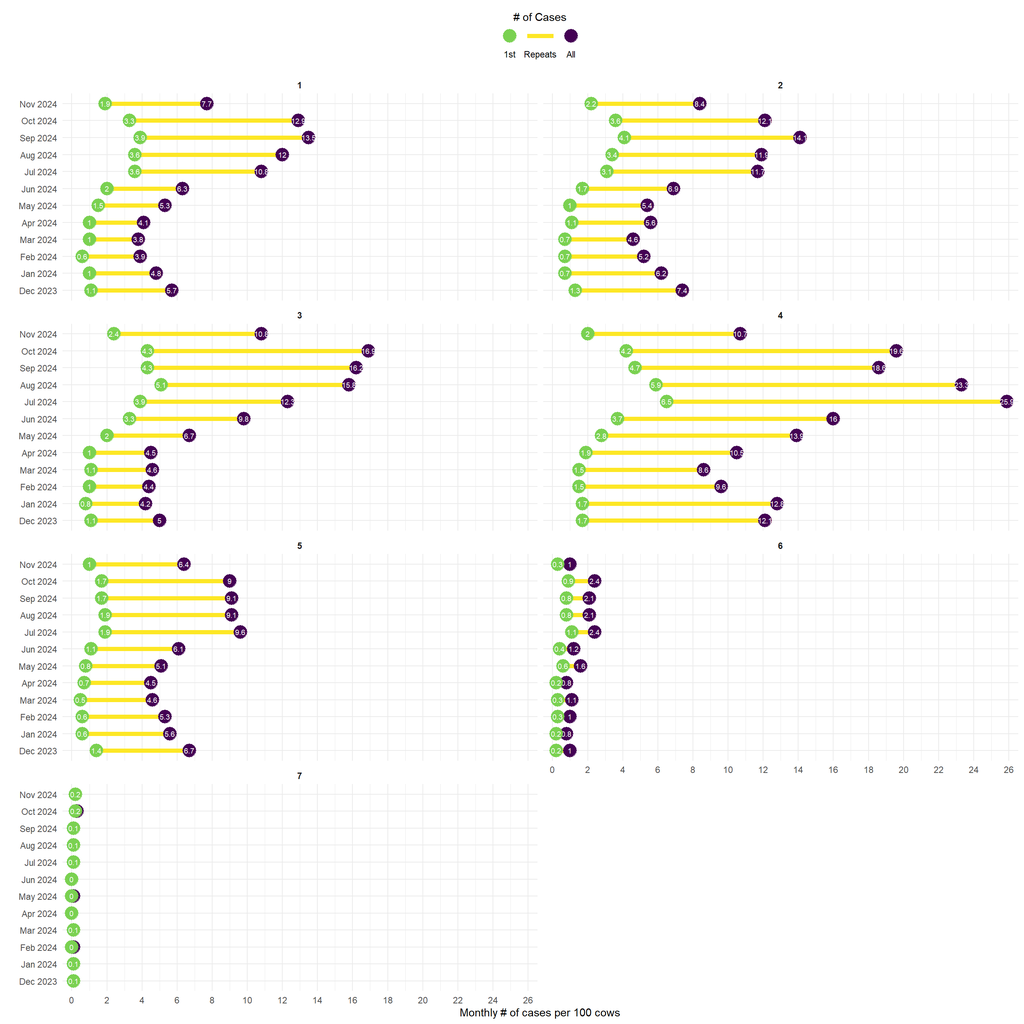

Figure 6: Seasonal Occurence of Lesions Current Year

**Previous Year**

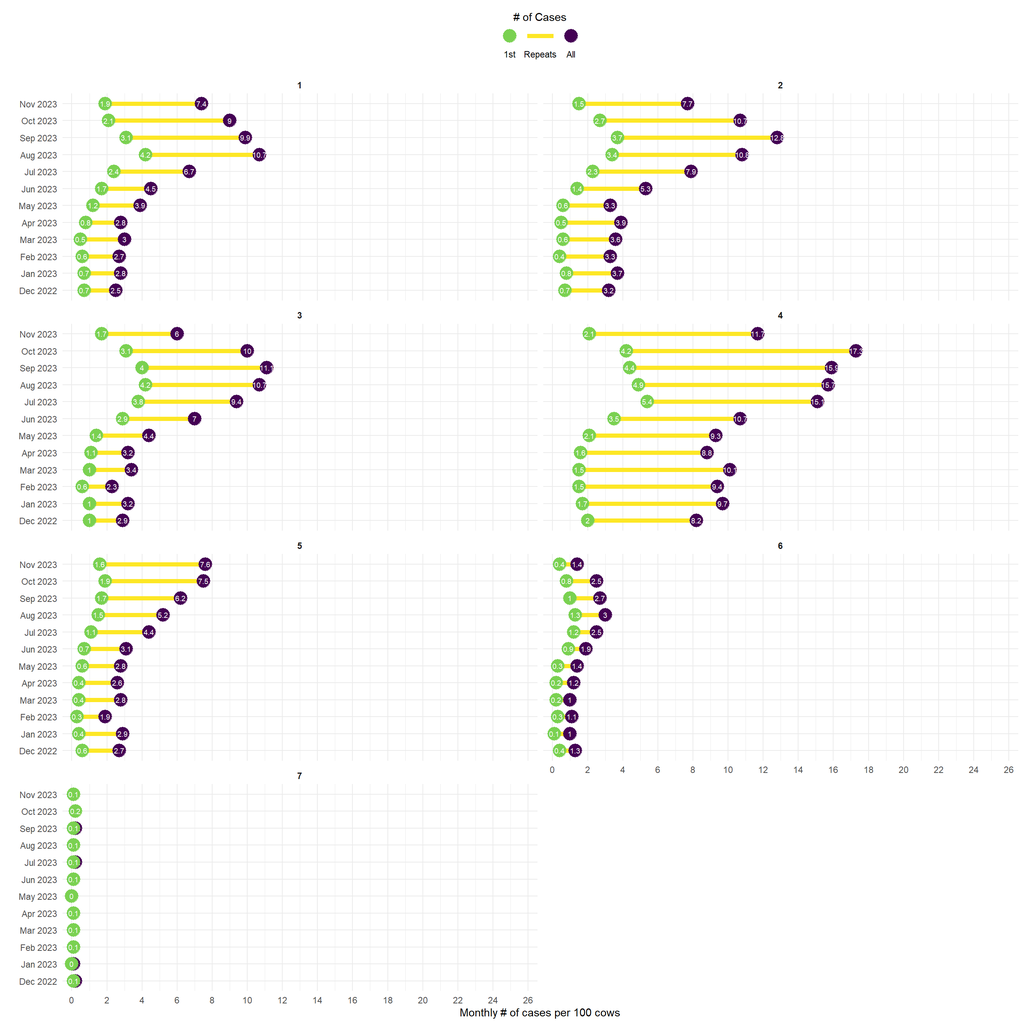

Figure 7: Seasonal Occurence of Lesions Past Year

## Infectious Lesions

**2024**

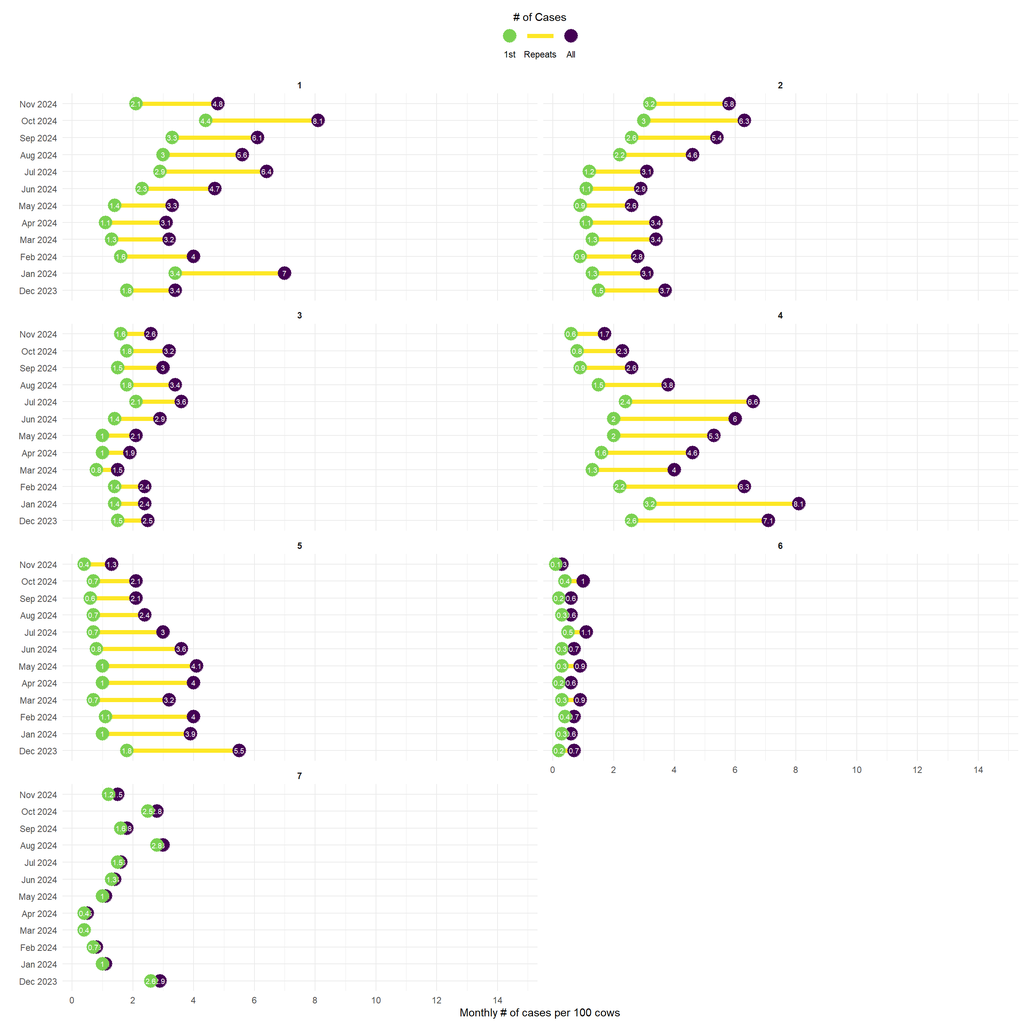

Figure 8: Seasonal Occurence of Lesions Current Year

**Previous Year**

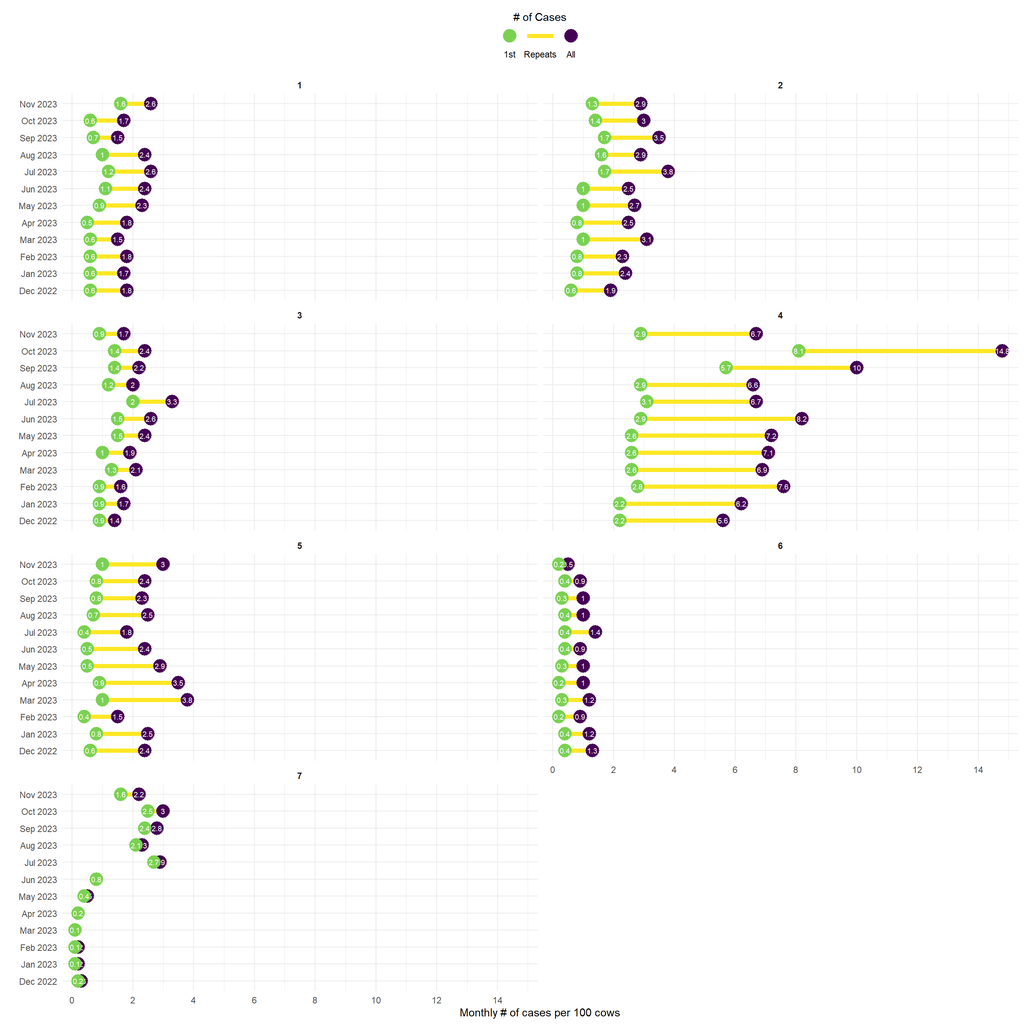

Figure 9: Seasonal Occurence of Lesions Past Year

# What is Success of Treatment?

The tables below show the % of cows in the last year that had a lesion and repeated that lesions. This is at the cow level not necessarily repeated on the same leg. Repeats occur because either the cow had a lesion on a different foot or because treatment did not help the cow. A repeat case is considered the next time a cows cows in the chute with the same lesion and time is not accounted for as if it was within a few days or a month later both take us trimmer and chute time.

## Time to Next Lesion

Figure 10 and Table 1 show how soon after having a *non-infectious lesion* cows are back in the chute with another lesion. It is important to look at this as if the repeats happen quickly after treatment, and it suggests that the treatment and detection protocol needs to be improved.

Figure 10: The longer and closer the 100% the line the better

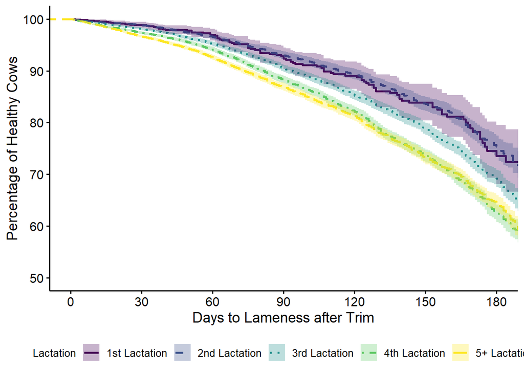

### Table

Table 1: Time to lameness after a cow’s first non infectious lesion at specific time points

| Lactation | % Lame (Confidence Interval) at 7 Days | % Lame (Confidence Interval) at 14 Days | % Lame (Confidence Interval) at 28 Days | % Lame (Confidence Interval) at 90 Days | % Lame (Confidence Interval) at 180 Days |
| --- | --- | --- | --- | --- | --- |
| 1 | 0.3% (<0.1%, 0.6%) | 0.5% (0.1%, 0.8%) | 1.1% (0.6%, 1.7%) | 7.6% (5.5%, 9.7%) | 26% (21%, 32%) |
| 2 | 0.4% (0.3%, 0.5%) | 0.7% (0.5%, 0.8%) | 1.1% (0.9%, 1.4%) | 7.0% (6.2%, 7.8%) | 25% (23%, 27%) |
| 3 | 0.4% (0.3%, 0.6%) | 1.0% (0.8%, 1.1%) | 1.8% (1.6%, 2.0%) | 9.6% (8.9%, 10%) | 31% (29%, 32%) |
| 4 | 0.8% (0.6%, 0.9%) | 1.4% (1.2%, 1.6%) | 2.5% (2.3%, 2.8%) | 12% (11%, 12%) | 38% (36%, 39%) |
| 5+ | 0.7% (0.6%, 0.9%) | 1.5% (1.3%, 1.7%) | 3.1% (2.9%, 3.4%) | 13% (12%, 14%) | 36% (34%, 37%) |

# Survival of cows after treatment for lesions

The following figures illustrate how quickly after a lesion diagnosis cows are culled (sold/died).

## Non-Infectious Lesions

From Figure 11 it is clear from that cows with lesions get culled faster than cows with no lesions at hoof trimming.

Figure 11: Cows with lesoins get culled faster and survival is worse for each repeated case.

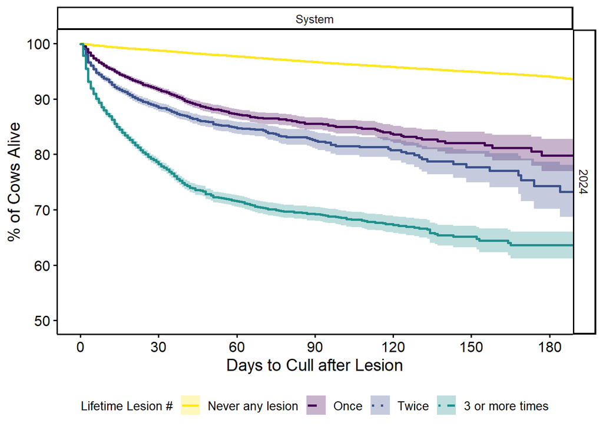

### Table

| Lifetime Lesion History | % Culled (Confidence Interval) at 30 Days | % Culled (Confidence Interval) at 120 Days | % Culled (Confidence Interval) at 180 Days |
| --- | --- | --- | --- |
| Never any lesion | 1.2% (0.9%, 1.5%) | 4.0% (3.5%, 4.6%) | 5.5% (4.8%, 6.1%) |
| Once | 7.7% (5.6%, 9.9%) | 13% (7.6%, 18%) | 13% (7.6%, 18%) |
| Twice | 12% (8.6%, 15%) | 20% (12%, 28%) | 29% (8.7%, 45%) |
| 3 or more times | 22% (19%, 25%) | 36% (29%, 43%) | 36% (29%, 43%) |

## Infectious Lesions

These graphs shows the impact of infectious lesions on time to culling

Figure 12: Cows with lesoins get culled faster and survival is worse for each repeated case.

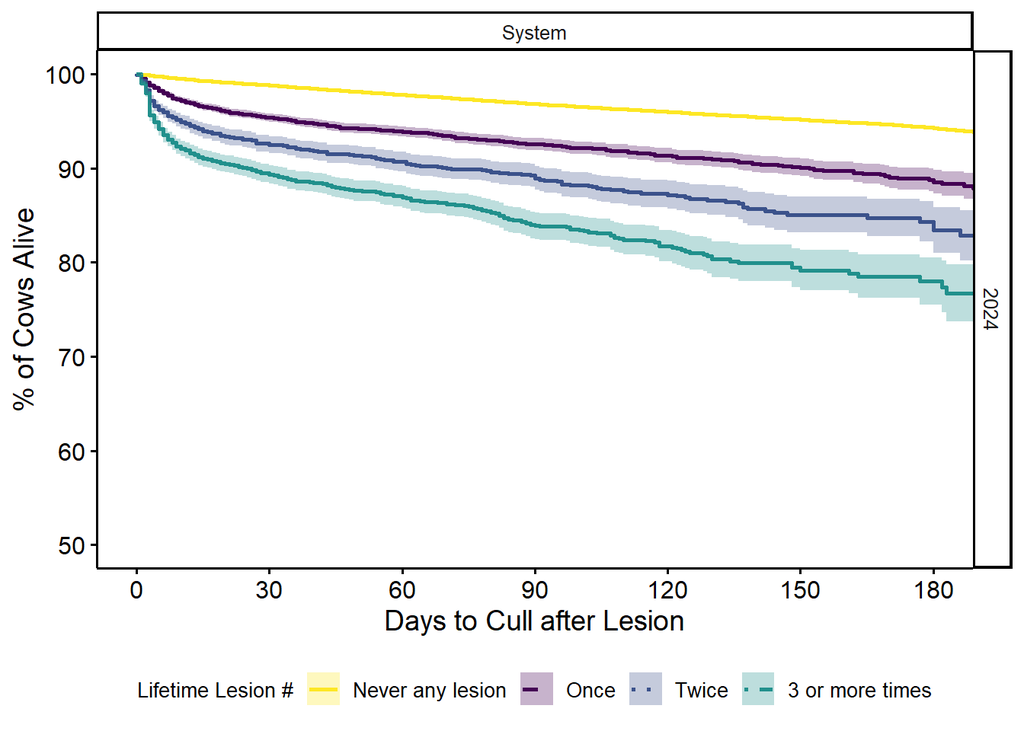

### Table

| Lifetime Lesion History | % Culled (Confidence Interval) at 30 Days | % Culled (Confidence Interval) at 120 Days | % Culled (Confidence Interval) at 180 Days |
| --- | --- | --- | --- |
| Never any lesion | 1.2% (0.9%, 1.4%) | 3.6% (3.1%, 4.1%) | 5.5% (4.8%, 6.2%) |
| Once | 4.0% (2.2%, 5.8%) | 7.7% (4.5%, 11%) | 10% (5.5%, 14%) |
| Twice | 7.5% (3.5%, 11%) | 13% (6.7%, 18%) | 24% (6.4%, 38%) |
| 3 or more times | 9.3% (5.2%, 13%) | 17% (10%, 24%) | 17% (10%, 24%) |